# Logistic Regression In Stroke and Non Stroke Patients

Chloé Winters

10/27/2024

# 1 Introduction

This assignment will continue the analysis the stroke prediction data set analyzed in previous assignments. It will further look into finding the best model for prediciting a stroke, this time through the use of cross validation.

# 2 Materials

## 2.1 Data Set

The World Health Organization (WHO) has reported that the second leading causes of deaths worldwide, responsible for approximately 11% of deaths, is a stroke. Due to strokes being the cause of death for 11% of the population, this data set was created to help identify potential risk factors such as BMI, avverage glucose level, age, and smoking status, and hopefully predict a patients likelihood of having a stroke. Unfortunately, there is no further information on the collection methods of this data set or who collected the data.

```r
url="https://ChloeWinters79.github.io/STA321/Data/healthcare-dataset-stroke-data.csv"
stroke.0 = read.csv(url, header = TRUE)
```

The data set, called stroke prediction, has 12 variables and they are as follows

1. id: (num) unique identifier
2. gender: (chr) “Male”, “Female”, “Other”
3. age: (num) Age (Years)
4. hypertension: (int) 0 = no hypertension, 1 = hypertension
5. heart_disease: (int) 0 = no heart disease, 1 = heart disease
6. ever_married: (chr) “No”, “Yes”
7. work_type: (chr) “Govt_job”, “Never_worked”, “Private”, “Self-employed”
8. Residence_type: (chr) “Rural”, “Urban”
9. avg_glucose_level: (num) average glucose level in blood
10. bmi: (num) body mass index
11. smoking_status (chr): “formerly smoked”, “never smoked”, “smokes”, “Unknown”
12. stroke: (int) 0 = no stroke, 1 = stroke

Of the 12 variables inside the data set, the first is ID which is a numerical variable but not one important in this analysis, there are 5 character variables, 3 binary response variables, and 3 numerical variables that are important to the analysis.

## 2.2 Data Cleaning

After reading in the data set, it was discovered that BMI was listed as a character variable due to the missing values being manually entered in as “N/A”. To correct this, all observations with a BMI of “N/A” were removed from the data set and BMI was converted into a numerical variable. The removable of these observations resulted in a removal of approximately 4% of the data set. Since this removal was not a significant proportion of the data set it should not have a significant impact on the final analysis and results.

Additionally, the ID variable was moved because it would not have a statistical significance on the data and is not necessary for the analysis that will be preformed. A subset of the stroke data set was also created to contain solely the continuous numerical variables, those being, age, avg_glucose_level and bmi. The purpose of this subset is to have an easily accessible data set for when only numerical analysis needs to be run.

```r
stroke.1 = subset(stroke.0, bmi != "N/A")
stroke.1 = subset(stroke.1, gender != "Other")
stroke.1$bmi = as.numeric(stroke.1$bmi)
stroke = subset(stroke.1, select = -c(id))
stroke$age = round(stroke$age, digits = 0)
stroke.num = subset(stroke, select = c(age, avg_glucose_level, bmi))
```

After undergoing the data cleaning process, we are left with a final data set that is ready for the data analysis process of this assignment.

# 3 Methodology & Analysis

Since the WHO has identified stroke as the second leading cause of death around the world, finding what aspects of a patients health history and lifestyle may impact the likelihood of having a stroke is very important. This assignment is going to use binary predictive modeling with the use of the logistic regression model to determine the best model for predicting strokes from this data set.

## 3.1 Variable Analysis & Transformation

First, it is important to start with a pairwise scatter plot of the numerical variables to asses their distribution. In addition to assessing if they have a normal distribution and are unimodel, it is important to see if any of the variables have significant correlation. If any of the variables had a significant correlation we would need to worry about redundancy and possibly having to remove one of the variables. Additionally, if any of the variables are not unimodal and normally distributed, they may have to undergo some variable transformation.

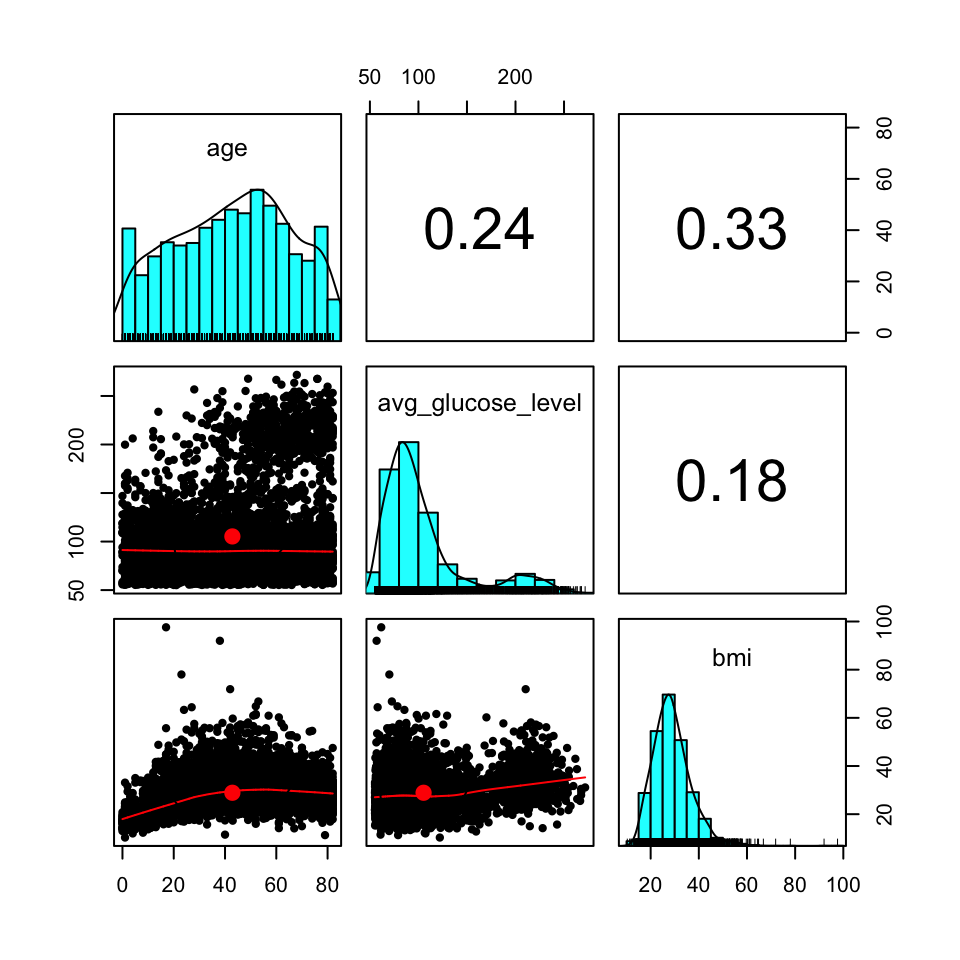

```r
library(psych)
pairs.panels(stroke.num[, -4],
             method = "pearson", # correlation method
             hist.col = "cyan",
             density = TRUE,  # show density plots
             ellipses = TRUE # show correlation ellipses
             )
```

```r
age = stroke$age

grp.age = age
grp.age[age %in% c(0:5)] = "0-5"
grp.age[age %in% c(6:15)] = "06-15"
grp.age[age %in% c(16:25)] = "16-25"
grp.age[age %in% c(26:35)] = "26-35"
grp.age[age %in% c(36:45)] = "36-45"
grp.age[age %in% c(46:55)] = "46-55"
grp.age[age %in% c(56:65)] = "56-65"
grp.age[age %in% c(66:75)] = "66-75"
grp.age[age %in% c(76:1000)] = "75+"

stroke$grp.age = grp.age
```

There does not appear to be a significant correlation between any of the three continuous numerical variables. Thus, none of the variables need to be dropped or seem to be at risk for being redundant

## 3.2 Data Split - Training and Testing Data

The data set will randomly be split into two subsets, the training data and the testing data. The training data will use 80% of the data and the testing data will use 20% of the data set. The training data will be used to search the candidate models in order to determine the final model using the cross-validation method. The testing data will be used to asses the final model selected with the training data.

Additionally, since the goal of this assignment is to determine which model has the best predictive performance it is not necessary to be concerned about the interpretation of the coefficients. Since the interpretation is not important, it is possible to standardize the numerical values even though standardizing the variables is not always considered best practice.

```r
stroke$sd.glucose = (stroke$avg_glucose_level-mean(stroke$avg_glucose_level))/sd(stroke$avg_glucose_level)
stroke$sd.bmi = (stroke$bmi-mean(stroke$bmi))/sd(stroke$bmi)
sd.stroke = subset(stroke, select = -c(avg_glucose_level, bmi))
```

```r
n <- dim(sd.stroke)[1]
train.n <- round(0.8*n)
train.id <- sample(1:n, train.n, replace = FALSE)
train <- sd.stroke[train.id, ]
test <- sd.stroke[-train.id, ]
```

After standardizing the numerical variables, BMI, and avg_glucose_level we were able to properly create the training and test data sets. These two data sets will be used in the analysis on the canidate models below.